# Data Diary Feb 20

Ignacio Calderon

2/16/2021

## Source

For this graphic I used data from [Good Job First](https://violationtracker.goodjobsfirst.org/prog.php?major_industry_sum=agribusiness)

Their violation tracker allows you to compile all the penalties from an industry.

1. There, I selected **agribusiness.**
2. You can see the top companies and if you go at the bottom you can download a csv with all the entries since 2000.
3. This csv has environmental related penalties as well as worker safety and other types. So from here I imported it in R to clean it up.

## Import into R

```r
#the raw data has 1034 rows and 34 columns
agribusiness <- read_csv("Data/agribusiness.csv")
#this just changes the spaces in the columns names for dots, easier to handle later
colnames(agribusiness) <- make.names(colnames(agribusiness))
```

## Clean up

1. I removed all the unnecessary columns so that we are left with:

Parent Company, Facility State, Penalty Amount (adjusted in case there were duplicates), and Offense Group (since we mentioned this has many types).

```r
agribusiness <- select(agribusiness,
                       Parent.Company,
                       Facility.State,
                       Penalty.Amount.Adjusted=Penalty.Amount.Adjusted.For.Eliminating.Multiple.Counting,
                       Offense.Group)
```

2. We will filter Offense Groups so that we are only left with environmental penalties .

```r
#this reduces to 385 obs. of 4 variables
agribusiness <- filter(agribusiness, Offense.Group == "environment-related offenses")

#not all entries have states, remove empty ones
#this reduces to 265 obs. of 4 variables
agribusiness <- filter(agribusiness, Facility.State != "")
```

```r
#group data by facility state
pivot <- group_by(agribusiness, Facility.State) %>%
  summarise(Total.Penalty=sum(Penalty.Amount.Adjusted)) %>%
  arrange(desc(Total.Penalty))

#top 5 states by environmental fines
top5 <- head(pivot, 5) %>%
  mutate(Total.Penalty.Millions=round(Total.Penalty/1000000, digits = 1))

datatable(top5)
```

|  | Facility.State | Total.Penalty | Total.Penalty.Millions |
| --- | --- | --- | --- |
| 1 | Indiana | 20876374 | 20.9 |
| 2 | Michigan | 13483900 | 13.5 |
| 3 | Iowa | 9298588 | 9.3 |
| 4 | Kansas | 6331856 | 6.3 |
| 5 | Texas | 3326568 | 3.3 |

## Data Viz

5. For the fun part, let’s look at them in an ugly bar graph.

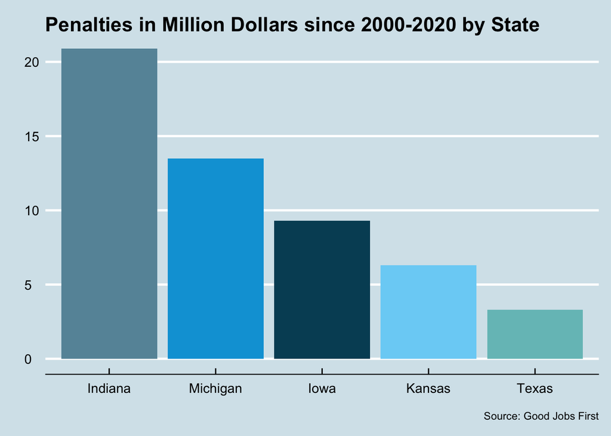

6. I exported this pivot table to make a prettier and interactive graph in Flourish.